# Rešenje zadatka

Vojkan Milijašević

12/7/2020

# 1 Princip rešavanja zadatka

Na osnovu dobijenih podataka (`niv_merenja.xlsx`) izvršeno je sledeće:

- Učitavanje Excel fajla
- Primena funkcije `nivelman` na svaki nivelmanski vlak
- Kreiranje sumarnih tabela `tabela1sve` (koja se odnosi na merenja na stanici) i `tabela2sve` (koja se odnosi na merenja od repera do repera)

# 2 Učitavanje Excel fajla

Excel fajl `niv_merenja` je organizovan tako da su merenja u pojedinačnim vlakovima smeštena u odvojenim sheet-ovima. Ovde će biti prikazana dva načina učitavanja tog fajla:

1. Učitavanje Excel fajla pomoću `purrr` paketa
2. Učitavanje Excel fajla pomoću `rio` paketa

Zbog potreba u ovom zadatku za `purrr` paketom i drugim paketima koji su sastavni deo kolekcije paketa `tidyverse` izvršeno je učitavanje kolekcije paketa tidyverse. Takođe, za potrebe zadatka izvršeno je učitavanje paketa `readxl` i `rio`.

## 2.1 Učitavanje Excel fajla pomoću `purrr` paketa

Za potrebe rešavanja ovog zadatka, ovaj pristup nije korišćen, te će u nastavku biti prezentovan kao moguća opcija.

Potrebno je definisati promenljivu koja predstavlja putanju do Excel fajla sa podacima.

```r
putanja <- ".../niv_merenja.xlsx"
```

Zatim se vrši kreiranje liste (`lista1`) u kojoj će svaki član liste biti jedna tabela (jedan excel sheet, odnosno jedan nivelmanski vlak).

```r
lista1 <- putanja %>%
  readxl::excel_sheets() %>%
  purrr::set_names() %>%
  purrr::map(readxl::read_excel, path = putanja)
```

Obratiti pažnju na funkciju **map** iz paketa `purrr`. Više o toj funkciji možete pogledati na sajtu tidyverse paketa, konkretno u delu koji je posvećen [readxl](https://readxl.tidyverse.org/articles/articles/readxl-workflows.html#iterate-over-multiple-worksheets-in-a-workbook) paketu.

## 2.2 Učitavanje Excel fajla pomoću `rio` paketa

Pomoću ovog paketa, korišćenjem funkcije **import_list** izvršeno je kreiranje liste (`lista1`) u kojoj je svaki član liste jedna tabela (jedan excel sheet, odnosno jedan nivelmanski vlak).

```r
lista1 <- rio::import_list(".../niv_merenja.xlsx")
```

# 3 Primena funkcije `nivelman` na svaki nivelmanski vlak

Definišu se reperi u mreži:

```r
reperi <- c("B1", "B3", "B4", "B5", "B6", "B7", "B8", "B9", "S1", "S2", "S3", "D1", "H1", "J1", "M1", "P1", "D7", "H7", "N7", "D10", "E10", "I10", "P10", "P13", "L116", "D19", "G19", "J19", "M19", "P19", "E26", "P26", "D29", "J29", "M29", "P29", "D32", "H32", "D38", "G38", "J38", "M38", "P38", "A11", "A12", "A13", "A14", "A21", "A22", "A23", "A24")
```

Zatim se vrši kreiranje prazne liste `lista2`.

Posle toga se kroz **for** petlju vrši primenjivanje funkcije `nivelman` na svaki član (na svaku tabelu) u listi `lista1` i vrši ubacivanje dobijenih rezultata u novu listu `lista2`.

```r
for(i in 1:length(lista1)) {
  lista2[[i]] <- nivelman(lista1[[i]], reperi)
  }
```

Svaki član u listi `lista2` će se sastojati od liste koja sadrzi dva člana (dve tabele) (`tabela1` - odnosi se na merenja na stanici u okviru nivelmanskog vlaka i `tabela2` - odnosi se na merenja od repera do repera u okviru nivelmanskog vlaka) koje su rezultat primene funkcije nivelman.

Zatim je izvršen grafički prikaz prvog člana liste `lista2` (to jest prvog nivelmanskog vlaka) i to tabele `tabela1`:

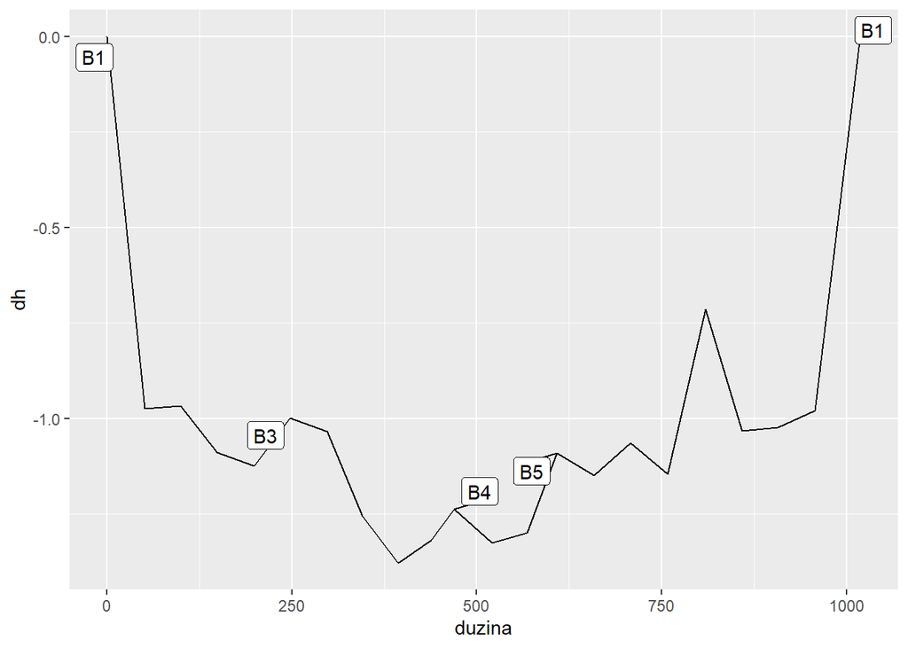

# 4 Kreiranje tabela `tabela1sve` i `tabela2sve`

Nakon izvršenih koraka, potrebno je:

- Spojiti dobijene tabele `tabela1` iz liste `lista2` kako bi se dobila sumarna tabela `tabela1sve` (koja se odnosi na merenja na stanici)
- Spojiti dobijene tabele (`tabela2`) iz liste `lista2` kako bi se dobila sumarna tabela `tabela2sve` (koja se odnosi na merenja od repera do repera).

Najpre se vrši kreiranje praznih tabela `tabela1sve` i `tabela2sve`.

Nakon toga, vrši se potrebno spajanje kroz **for** petlju i korišćenjem funkcije **rbind**.

```r
for(i in 1:length(lista2)) {
  tabela1sve <- rbind(tabela1sve, lista2[[i]][[1]])
  tabela2sve <- rbind(tabela2sve, lista2[[i]][[2]])
}
```

Prikaz prvih 10 redova tabele `tabela1sve`:

tabela1sve (prvih 10 redova)

| od | do | dh | duzina |
| --- | --- | --- | --- |
| B1 | 1 | -0.973905 | 51.185 |
| 1 | 2 | 0.006950 | 47.885 |
| 2 | 3 | -0.121490 | 49.485 |
| 3 | 4 | -0.035755 | 50.790 |
| 4 | B3 | 0.125845 | 48.295 |
| B3 | 1 | -0.035680 | 49.735 |
| 1 | 2 | -0.220535 | 47.665 |
| 2 | 3 | -0.125240 | 48.165 |
| 3 | 4 | 0.060390 | 45.570 |
| 4 | B4 | 0.082415 | 30.905 |

Prikaz prvih 10 redova tabele `tabela2sve`:

tabela2sve (prvih 10 redova)

| od | do | dh | n | duzina |
| --- | --- | --- | --- | --- |
| B1 | B3 | -0.998355 | 5 | 247.640 |
| B3 | B4 | -0.238650 | 5 | 222.040 |
| B4 | B5 | 0.145455 | 3 | 138.825 |
| B5 | B1 | 1.092920 | 8 | 410.205 |
| B5 | B6 | 0.189085 | 8 | 343.480 |
| B6 | B7 | 0.168180 | 5 | 185.670 |
| B7 | B8 | -0.323950 | 5 | 206.295 |
| B8 | B9 | 0.406310 | 5 | 224.305 |
| B9 | B1 | 0.656605 | 9 | 385.940 |
| S3 | D38 | 0.360160 | 1 | 47.620 |